# IMDB Shiny Application

1. So far, all of our Shiny applications have been based on toy simulated data. In this set of notes, we’ll use Shiny to explore a real dataset, illustrating the general development workflow in the process. Before diving into code, let’s consider the role of interactivity in data analysis.
2. A major difference between doing visualization on paper and on computers is that visualization on computers can make use of interactivity. An interactive visualization is one that changes in response to user cues. This allows a display to update in a way that provides a visual comparison that was not available in a previous view. In this way, interactive visualization allows users to answer a sequence of questions.
3. Selection, both of observations and of attributes, is fundamental to interactive visualization. This is because it precedes other interactive operations: you can select a subset of observations to filter down to or attributes to coordinate across multiple displays (we consider both types of interactivity in later lectures).
4. The code below selects movies to highlight based on Genre. We use a `selectInput` to create the dropdown menu. A reactive expression creates a new column (`selected`) in the `movies` dataset specifiying whether the current movie is selected. The reactive graph structure means that the ggplot2 figure is recreated each time the selection is changed, and the `selected` column is used to shade in the points. This process of changing the visual encoding of graphical marks depending on user selections is called “conditional encoding.”

[interactive chart not shown]

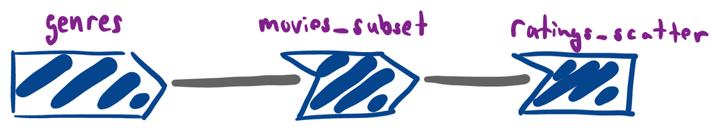

   ```r
   library(shiny)
   library(tidyverse)
   library(lubridate)

   movies <- read_csv("https://raw.githubusercontent.com/krisrs1128/stat479_s22/main/_posts/2022-02-10-week04-03/apps/data/movies.csv") %>%
     mutate(
       date = as_date(Release_Date, format = "%b %d %Y"),
       year = year(date),
       Major_Genre = fct_explicit_na(Major_Genre),
       MPAA_Rating = fct_explicit_na(MPAA_Rating),
     )

   genres <- pull(movies, Major_Genre) %>%
     unique() %>%
     na.omit()

   ### functions used in app
   scatterplot <- function(df) {
     ggplot(df) +
       geom_point(
         aes(Rotten_Tomatoes_Rating, IMDB_Rating, size = selected, alpha = selected)
       ) +
       scale_size(limits = c(0, 1), range = c(.5, 2), guide = "none") +
       scale_alpha(limits = c(0, 1), range = c(.1, 1), guide = "none")
   }

   ### definition of app
   ui <- fluidPage(
     titlePanel("IMDB Analysis"),
     selectInput("genres", "Genre", genres),
     plotOutput("ratings_scatter")
   )

   server <- function(input, output) {
     movies_subset <- reactive({
       movies %>%
         mutate(selected = 1 * (Major_Genre %in% input$genres))
     })

     output$ratings_scatter <- renderPlot({
       scatterplot(movies_subset())
     })
   }

   app <- shinyApp(ui, server)
   ```

5. We can extend this further. Let’s allow the user to filter by year and MPAA rating. Notice that there are some years in the future! We also find that there are systematic differences in IMDB and Rotten Tomatoes ratings as a function of these variables.

Also notice the subtle introduction of a new concept; the double-sided slider! Providing a 2-length vector to the `values` argument; that is, `c(1928, 2020)`; will define an upper and lower bound on the slider that the user can tinker with. The consequence of this is that calling `input$year` down in the server now returns a 2-length vector for the locations of both ends, such that `input$year[1]` refers to the lower bound and `input$year[2]` refers to the upper bound.

[output not shown]

1. We’ll include a final version of this plot which additionally shows the movie name when points are hovered. To accomplish this, we can no longer use `ggplot2` on its own – it has to be linked with a plotting library that renders web-based visualizations (not just static image files). This is what the `ggplotly()` call does in the updated version of the app. The mouseover text is added through the `tooltip` argument.

   ```r
   library(shiny)
   library(tidyverse)
   library(lubridate)
   library(plotly)

   movies <- read_csv("https://raw.githubusercontent.com/krisrs1128/stat479_s22/main/_posts/2022-02-10-week04-03/apps/data/movies.csv") %>%
     mutate(
       date = as_date(Release_Date, format = "%b %d %Y"),
       year = year(date),
       Major_Genre = fct_explicit_na(Major_Genre),
       MPAA_Rating = fct_explicit_na(MPAA_Rating),
     )

   genres <- pull(movies, Major_Genre) %>%
     unique() %>%
     na.omit()
   ratings <- pull(movies, MPAA_Rating) %>%
     unique() %>%
     na.omit()

   ### functions used in app
   scatterplot <- function(df) {
     p <- ggplot(mapping = aes(Rotten_Tomatoes_Rating, IMDB_Rating)) +
       geom_point(data = df %>% filter(selected),  aes(text = Title), size = 2, alpha = 1) +
       geom_point(data = df %>% filter(!selected),  size = .5, alpha = .1)
     ggplotly(p, tooltip = "Title") %>%
       style(hoveron = "fill")
   }

   ### definition of app
   ui <- fluidPage(
     titlePanel("IMDB Analysis"),
     selectInput("genres", "Genre", genres),
     checkboxGroupInput("mpaa", "MPAA Rating", ratings, ratings),
     sliderInput("year", "Year", min = min(movies$year), max = max(movies$year), c(1928, 2020), sep = ""),
     plotlyOutput("ratings_scatter")
   )

   server <- function(input, output) {
     movies_subset <- reactive({
       movies %>%
         mutate(selected = (
           (Major_Genre %in% input$genres) &
           (MPAA_Rating %in% input$mpaa) &
           (year >= input$year[1]) &
           (year <= input$year[2])
         ))
     })

     output$ratings_scatter <- renderPlotly({
       scatterplot(movies_subset())
     })
   }

   app <- shinyApp(ui, server)
   ```

[interactive chart not shown]

2. These visualizations are an instance of the more general idea of using filtering to reduce complexity in data. Filtering is an especially powerful technique in the interactive paradigm, where it is possible to easily reverse (or compare) filtering choices.
3. Conceptually, what we are doing falls under the name of “Dynamic Querying,” which refers more generally to updating a visualization based on user queries. There are several ways to think about these dynamic queries,
   - Interpretation 1: Dynamic queries create the visual analog of a database interaction. Rather than using a programming-based interface to filter elements or select attributes, we can design interactive visual equivalents.
   - Interpretation 2: Dynamic queries allow rapid evaluation of conditional probabilities. The visualization above was designed to answer: What is the joint distribution of movie ratings, conditional on being a drama?